# Additional Data Exploration

Last modified: 18 Jun 2024

# Introduction

In the exploration of RNA-seq data session we looked at how we could use principal component analysis to explore patterns in the samples related to the variation in the gene expression, and how these could inform us about how well our results conform to the experimental design.

The document shows some additional visualisations that should be run to further explore our data.

# Load the data

First let’s load the data and create the raw counts matrix as before. For the visualizations we will add a new column called `SampleGroup` to the sample meta data table that combines the Status and Time Point. This will allow us to visualise the four sample groups.

```r
library(DESeq2)
library(tidyverse)
library(patchwork)

# Read the sample information into R
sampleinfo <- read_tsv("data/samplesheet_corrected.tsv", col_types="cccc") %>%
                   mutate(Status = fct_relevel(Status, "Uninfected")) %>%
                   mutate(SampleGroup = str_c(Status, ".", TimePoint))

# Read the data into R
txi <- readRDS("RObjects/txi.rds")

rawCounts <- round(txi$counts, 0)

# create colour vectors for plots
statusCols <- c(Infected="#FF7F00", Uninfected="#33A02C")
samgrpCols <- c(Infected.d11="#FDBF6F", Infected.d33="#FF7F00",
                Uninfected.d11="#B2DF8A", Uninfected.d33="#33A02C")
```

# Samples

```r
sampleinfo
```

```
## # A tibble: 12 × 5
##    SampleName Replicate Status     TimePoint SampleGroup
##    <chr>      <chr>     <fct>      <chr>     <chr>
##  1 SRR7657878 1         Infected   d11       Infected.d11
##  2 SRR7657881 2         Infected   d11       Infected.d11
##  3 SRR7657880 3         Infected   d11       Infected.d11
##  4 SRR7657874 1         Infected   d33       Infected.d33
##  5 SRR7657882 2         Uninfected d33       Uninfected.d33
##  6 SRR7657872 3         Infected   d33       Infected.d33
##  7 SRR7657877 1         Uninfected d11       Uninfected.d11
##  8 SRR7657876 2         Uninfected d11       Uninfected.d11
##  9 SRR7657879 3         Uninfected d11       Uninfected.d11
## 10 SRR7657883 1         Uninfected d33       Uninfected.d33
## 11 SRR7657873 2         Infected   d33       Infected.d33
## 12 SRR7657875 3         Uninfected d33       Uninfected.d33
```

# Count density

In session 5 we looked at the distribution of the counts using a box plot. Another useful visualisation is to look at the density distribution of the counts.

Let’s take a look at the count density for one sample using the `density` function from the base `stats` package.

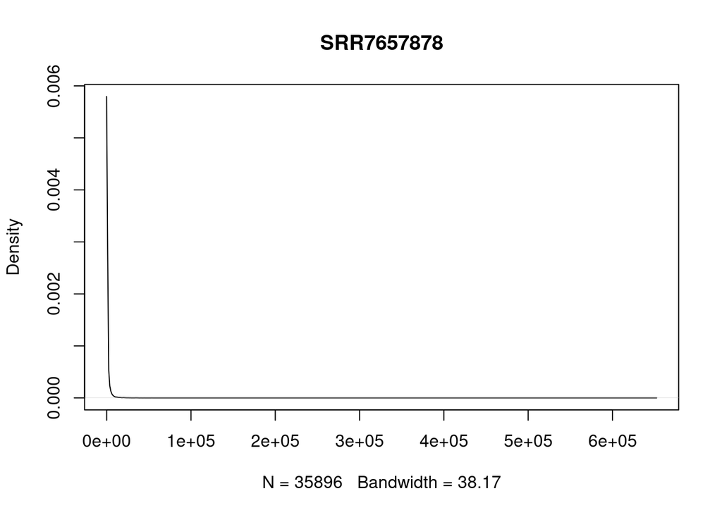

```r
dens <- density(rawCounts[,1])
plot(dens, main = colnames(rawCounts)[1])
```

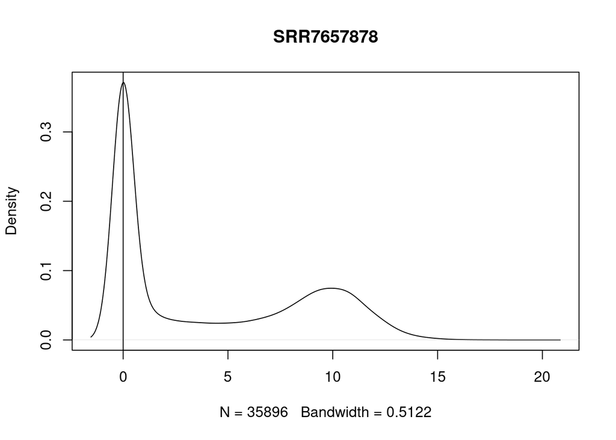

```r
logCounts <- log2(rawCounts + 1)
dens <- density(logCounts[,1])
plot(dens, main = colnames(logCounts)[1])
abline(v=0)
```

This is better, but we can see that we have a very large peak at 0, which is dominating the distribution pattern. As in session 7 we will remove genes with low read counts; these are likely unexpressed genes and the associated read counts are likely to be noise.

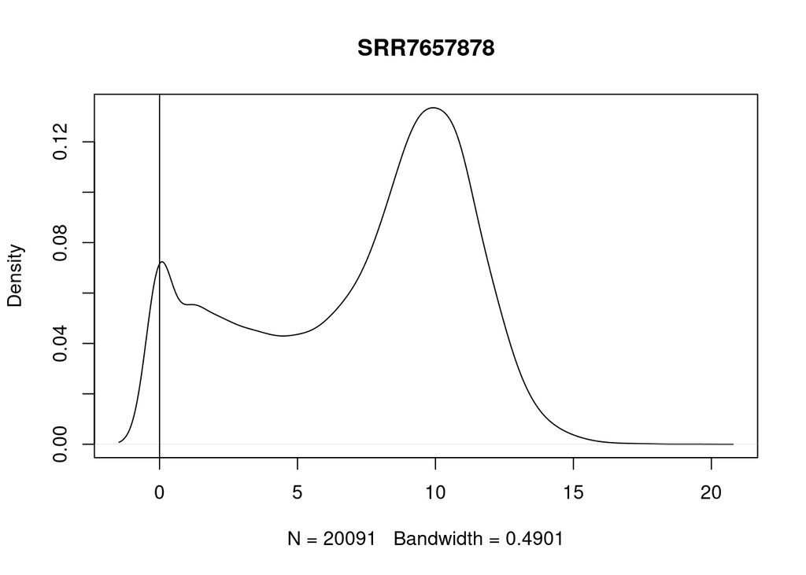

```r
keep <- rowSums(rawCounts) > 5
logCounts <- log2(rawCounts[keep, ] + 1)
dens <- density(logCounts[,1])
plot(dens, main = colnames(logCounts)[1])
abline(v=0)
```

We still have some noise at the lower end of the count distribution, but we can now assess the read count distribution for expressed genes. We could be more aggressive with the filtering, but this will suffice.

It would be more useful if we could plot all the samples together. We would usually expect that the overall distribution of read counts should be similar across all the samples. We could do this with the base R plotting functions, but it is a rather cumbersome process, so instead we will use ggplot, as introduced in the annotation and visualisation session.

`ggplot` requires the data to be in “tidy” format (also known as a “long formatted data frame”), so we will need to transform our data matrix using the `dplyr` function `pivot_longer`. `ggplot` has built in density plot, so won’t have to calculate the density first.

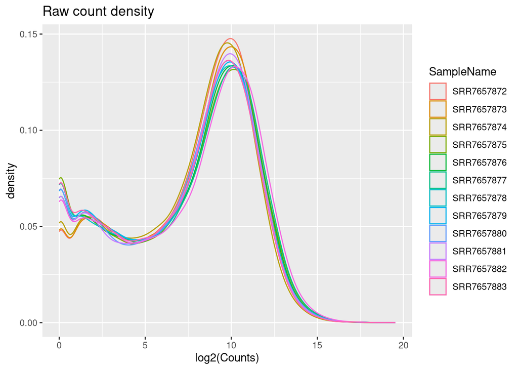

```r
logCounts %>%
    as.data.frame() %>%
    pivot_longer(names_to = "SampleName", values_to = "logCounts", everything()) %>%
    ggplot(aes(x=logCounts, group = SampleName)) +
        geom_density(aes(colour = SampleName)) +
        labs(x = "log2(Counts)", title = "Raw count density")
```

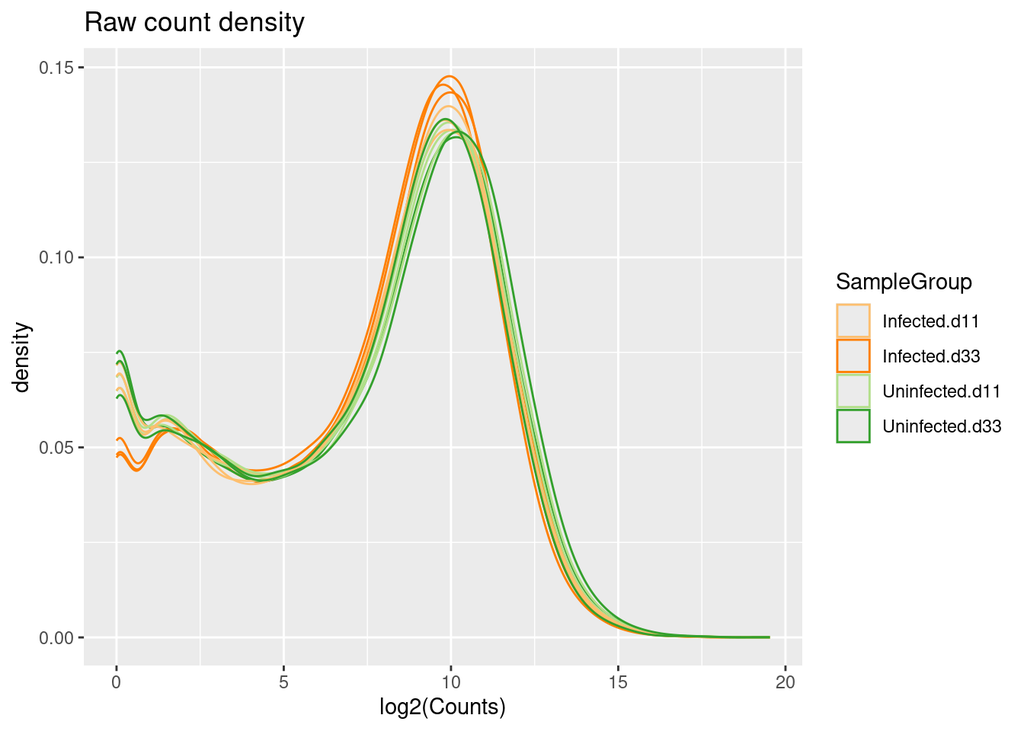

```r
logCounts %>%
    as.data.frame() %>%
    pivot_longer(names_to = "SampleName", values_to = "logCounts", everything()) %>%
    left_join(sampleinfo) %>%
    ggplot(aes(x=logCounts, group = SampleName)) +
        geom_density(aes(colour = SampleGroup)) +
        scale_colour_manual(values = samgrpCols) +
        labs(x = "log2(Counts)", title = "Raw count density")
```

We can see that all the samples have roughly similar distribution profiles, but that the infected samples show more variation in the distributions. We can now have a look to see how normalisation would effect the count density. We will use the `rlog` function from `DESeq2`.

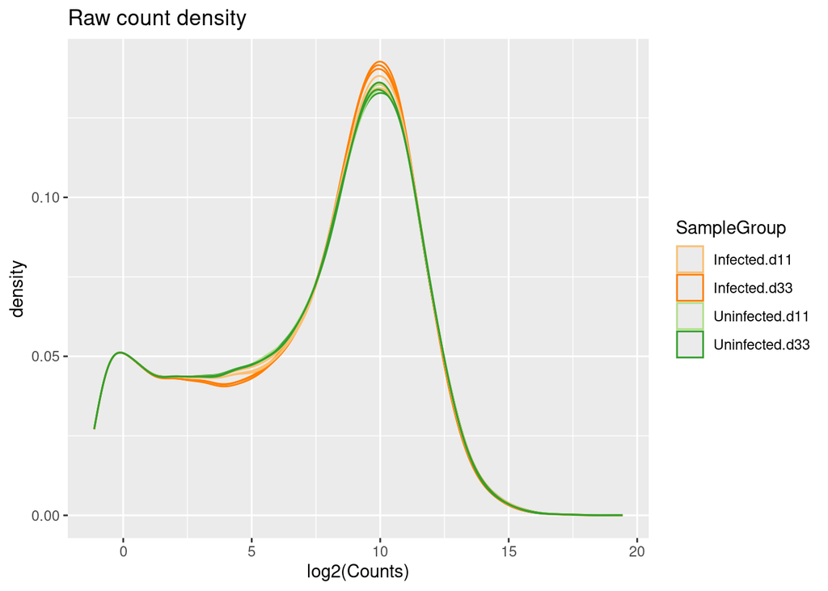

```r
rlogCnts <- rlog(rawCounts[keep, ])
rlogCnts %>%
    as.data.frame() %>%
    pivot_longer(names_to = "SampleName", values_to = "logCounts", everything()) %>%
    left_join(sampleinfo) %>%
    ggplot(aes(x=logCounts, group = SampleName)) +
       geom_density(aes(colour = SampleGroup)) +
        scale_colour_manual(values = samgrpCols) +
        labs(x = "log2(Counts)", title = "Raw count density")
```

From this we can see that the `rlog` normalisation for overall library size has brought the density distributions into similar ranges. We can see that it has smoothed out the wide variations in the noise level counts at the left of the plot. Furthermore, we can now observe that distribution of infected samples indicates that, relative to the uninfected samples, there are more genes in the 2^10 range and less in the 2^5 range. This would indicate a general pattern of upregulation.

# Hierachical clustering

In session 7 we used principle component analysis to assess sources of variation in the data set and the relationship between the samples. Another method for looking at the relationship between the samples can be to run hierarchical clustering based on the Euclidean distance between the samples. Hierarchical clustering can often provide a clearer view of the clustering of the different sample groups than other methods such as PCA.

We will use the package `ggdendro` to plot the clustering results using the function `ggdendrogram`.

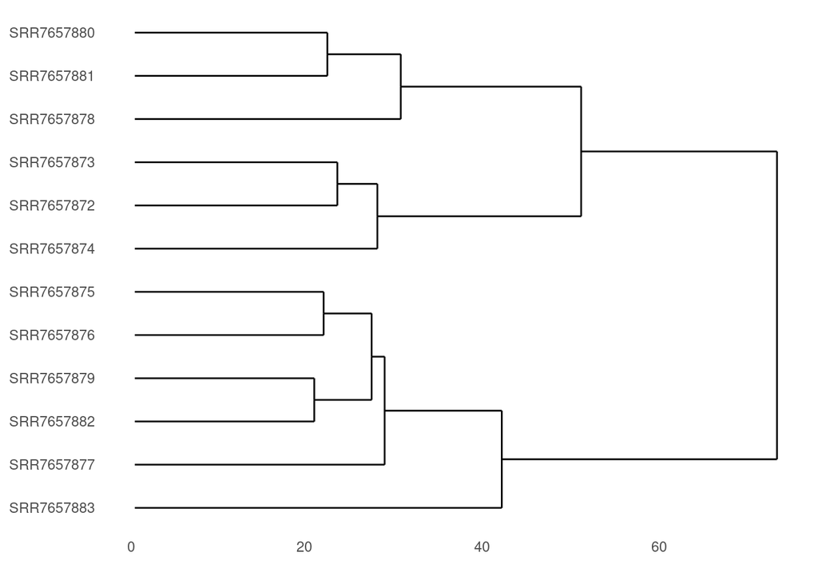

```r
library(ggdendro)
hclDat <-  t(rlogCnts) %>%
   dist(method = "euclidean") %>%
   hclust()
ggdendrogram(hclDat, rotate=TRUE)
```

We really need to add some information about the sample groups. The simplest way to do this would be to replace the `labels` in the `hclust` object. Conveniently the labels are stored in the `hclust` object in the same order as the columns in our counts matrix, and therefore the same as the order of the rows in our sample meta data table. We can just substitute in columns from the metadata.

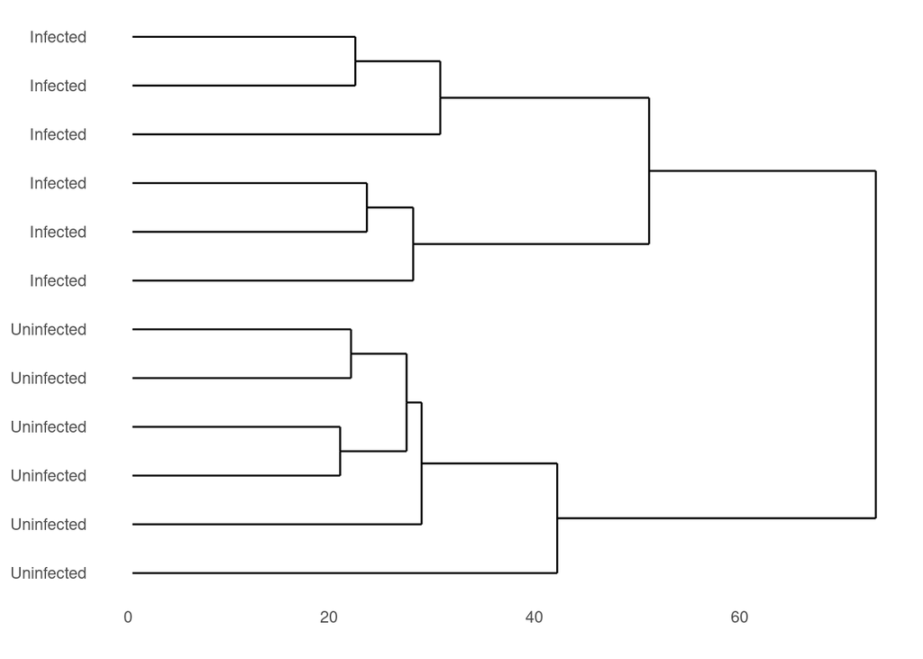

```r
hclDat2 <- hclDat
hclDat2$labels <- sampleinfo$Status
ggdendrogram(hclDat2, rotate=TRUE)
```

We can see from this that the infected and uninfected samples cluster separately. For the infected samples, the replicates from the time points also cluster separately, but for the uninfected samples there is no clear clustering by time point.

If we want to have more control over the look of the plot, we need to extract the dendrogram plotting information and create the plot manually using ggplot. We need to use two commands for this: `as.dendrogram` builds a dendrogram from the hierachical clustering results, then `dendro.data` extracts the details for plotting the dendrogram. The extracted object is a list with two tables: `segment` contains the x and y coordinates for drawing the lines of the dendrogram, `labels` contains the labels (sample names) and the x and y coordinates for plotting them. We can add additional meta data to the `labels` data frame.

In section below we’ve added a number of `theme` elements to the ggplot in order to remove the axes, the bounding box and the background grid. Please see the ggplot help pages for more information on themes.

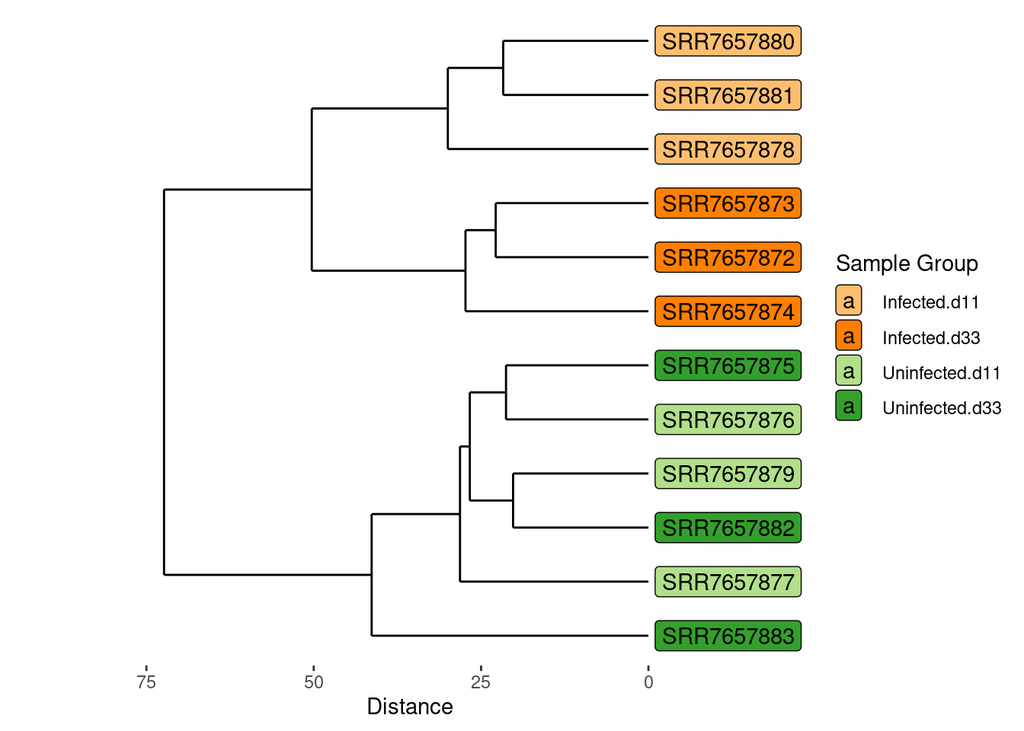

```r
dendro.dat <-as.dendrogram(hclDat) %>% dendro_data()

dendro.dat$labels <- dendro.dat$labels %>%
    left_join(sampleinfo, by = c(label = "SampleName"))

ggplot(dendro.dat$segment) +
    geom_segment(aes(x = x, y = y, xend = xend, yend = yend)) +
    geom_label(data = dendro.dat$labels,
              aes(x = x,
                  y = y,
                  label = label,
                  fill = SampleGroup),
                  hjust = 0,
                  nudge_y = 1) +
    scale_fill_manual(values = samgrpCols) +
    coord_flip() +
    labs(x = NULL, y = "Distance", title = NULL, fill = "Sample Group") +
    scale_y_reverse(expand = c(0.3, 0)) +
    theme(axis.title.y = element_blank(),
          axis.text.y = element_blank(),
          axis.ticks.y = element_blank(),
          panel.background = element_blank())
```

# Correlation plot

Another useful way to assess the relationships between our samples is to look at the pairwise correlations.

We will use the package `corrplot` to visualise the pairwise correlations.

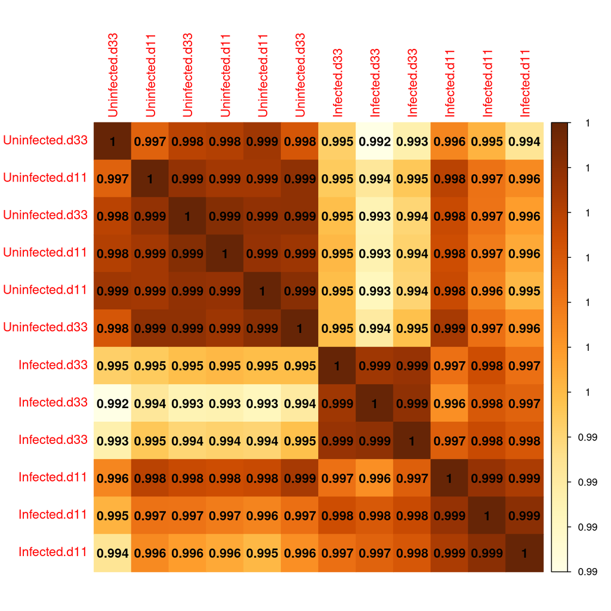

```r
library(corrplot)
corDat <- cor(rlogCnts)
rownames(corDat) <- sampleinfo$SampleGroup
colnames(corDat) <- sampleinfo$SampleGroup
col <- colorRampPalette(c("#FFFFFF", "#77AADD", "#4477AA"))
corrplot(corDat,
         method = "color",
         addCoef.col = "black",
         number.digits= 3,
         order = "hclust",
         is.corr = FALSE)
```

We can start to see the structure in our data set, but from the correlation coefficients it would appear that all of the samples are very similar. Indeed, this is true, most of the genes in the count matrix do not vary greatly in expression across the samples and so the pairwise correlations using all genes are very high.

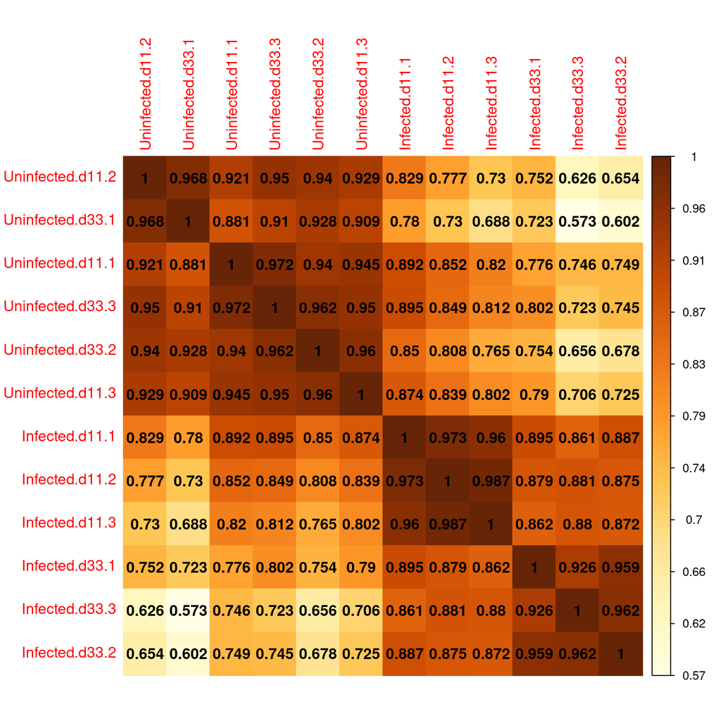

```r
vars <- rowVars(rlogCnts)
ord <- order(-vars)
corDat <- cor(rlogCnts[ord[1:500],])
rownames(corDat) <- str_c(sampleinfo$SampleGroup, ".", sampleinfo$Replicate)
colnames(corDat) <- str_c(sampleinfo$SampleGroup, ".", sampleinfo$Replicate)
corrplot(corDat,
         method = "color",
         addCoef.col = "black",
         number.digits= 3,
         order = "hclust",
         is.corr = FALSE)
```

We can see from this that for highly variable genes, the day 11 and day 33 uninfected samples are more closely correlation to one another than the day 11 and day 33 infected samples.

# Coda

It may not seem that we have learned much more about the data set from the clustering and correlation plots than we did from the principle component analysis, however, this is a very simple data set. In more complex situations with more nuanced relationships between sample groups, these additional plots can prove very informative.